# Geog533 Lab 6 - ANOVA

NANA AMA OBENG NTI

Complete the following exercises in Chapter 6 (Analysis of Variance) of the textbook pages 199-203. For each question, you need to specify the null hypothesis and why you accept or reject the null hypothesis.

## Question 1

This is Exercise 2 in Chapter 6 of the Textbook [R].

### Problem

Assume that an analysis of variance is conducted for a study where there are $N = 50$ observations and $k = 5$ categories. Fill in the blanks in the following ANOVA table:

|  | Sum of squares | Degrees of freedom | Mean square | *F* |
| --- | --- | --- | --- | --- |
| Between |  |  | 116.3 |  |
| Within | 2000 |  |  |  |
| Total |  |  |  |  |

### Solution

```r
N <- 50
k <- 5
df1 <- k - 1
df2 <- N - k
BMS <- 116.3
BSS <- BMS * df1
WSS <- 2000
WMS <- WSS / df2
TSS <- BSS + WSS
F.value <- BMS / WMS
q95 <- qf(0.95,df1,df2)
q95
```

```
[1] 2.578739
```

```r
if(F.value < q95) {
  print("We cannot reject the null hypothesis")
} else {
  print("we reject the null hypothesis")
}
```

```
[1] "we reject the null hypothesis"
```

```r
print("We reject the null hypothesis because the F.value falls within the Rejection Region, thus it is greater than the Critical Value making it less likely for the observations to be equal.")
```

```
[1] "We reject the null hypothesis because the F.value falls within the Rejection Region, thus it is greater than the Critical Value making it less likely for the observations to be equal."
```

|  | Sum of squares | Degrees of freedom | Mean square | *F* |
| --- | --- | --- | --- | --- |
| Between | 465.2 | 4 | 116.3 | 2.61675 |
| Within | 2000 | 45 | 44.4444444 |  |
| Total | 2465.2 |  |  |  |

## Question 2

This is Exercise 6 in Chapter 6 of the Textbook [R].

### Problem

Is there a significant difference between the distances moved by low- and high-income individuals? Twelve respondents in each of the income categories are interviewed, with the following results for the distances associated with residential moves:

| Respondent | Low income | High income |
| --- | --- | --- |
| 1 | 5 | 25 |
| 2 | 7 | 24 |
| 3 | 9 | 8 |
| 4 | 11 | 2 |
| 5 | 13 | 11 |
| 6 | 8 | 10 |
| 7 | 10 | 10 |
| 8 | 34 | 66 |
| 9 | 17 | 113 |
| 10 | 50 | 1 |
| 11 | 17 | 3 |
| 12 | 25 | 5 |
| Mean | 17.17 | 23.17 |
| Std. dev. | 13.25 | 33.45 |

Test the null hypothesis of homogeneity of variances by forming the ratio $s_1^2 / s_2^2$ which has an F-ratio with $n_1 – 1$ and $n_2 – 1$ degrees of freedom. Then use ANOVA (with $\alpha = 0.10$) to test whether there are differences in the two population means. Set up the null and alternative hypotheses, choose a value of α and a test statistic, and test the null hypothesis. What assumption of the test is likely not satisfied?

### Solution

```r
Low <- L <- c(5,7,9,11,13,8,10,34,17,50,17,25)
High <- c(25,24,8,2,11,10,10,66,113,1,3,5)
s1 <- 13.25^2
s2 <- 33.45^2
ratio <- s1 / s2
ratio
```

```
[1] 0.156906
```

```r
F.ratio <- df(0.90,11,11)
F.ratio
```

```
[1] 0.7077032
```

```r
df <- data.frame(cbind(Low,High))
df
```

| Low | High |
| --- | --- |
| 5 | 25 |
| 7 | 24 |
| 9 | 8 |
| 11 | 2 |
| 13 | 11 |
| 8 | 10 |
| 10 | 10 |
| 34 | 66 |
| 17 | 113 |
| 50 | 1 |

[output cut: 2 more lines]

```r
income <- stack(df)
income
```

| values | ind |
| --- | --- |
| 5 | Low |
| 7 | Low |
| 9 | Low |
| 11 | Low |
| 13 | Low |
| 8 | Low |
| 10 | Low |
| 34 | Low |
| 17 | Low |
| 50 | Low |

[output cut: 14 more lines]

```r
##Homogeneity of Variance
##Ho: Population Variance are Equal
library(car)
H.test <- leveneTest(values~ind, data = income)
H.test
```

```
Levene's Test for Homogeneity of Variance (center = median)
      Df F value Pr(>F)
group  1  1.0206 0.3234
      22
```

```r
print("Since p.value is 0.3234, we accept the null hypothesis that the population variance are equal.")
```

```
[1] "Since p.value is 0.3234, we accept the null hypothesis that the population variance are equal."
```

```r
##Difference in Population Mean
result <- aov(values~ind,data = income)
summary(result)
```

```
            Df Sum Sq Mean Sq F value Pr(>F)
ind          1    216   216.0   0.334  0.569
Residuals   22  14241   647.3
```

```r
##Critcal Value = q90 (with $\alpha = 0.10$)
q90 <- qf(0.90,1,24)
q90
```

```
[1] 2.927117
```

```r
print("Since the Critical value is greater than the F.value, we can conclude that there are no differences in the two population means and accept the null hypothesis.")
```

```
[1] "Since the Critical value is greater than the F.value, we can conclude that there are no differences in the two population means and accept the null hypothesis."
```

```r
## ASSUMPTION NOT LIKELY MET
#Ho:There is no significant difference between the distances moved by low- and high-income individuals
result <- kruskal.test(Low,High)
result
```

```
    Kruskal-Wallis rank sum test

data:  Low and High
Kruskal-Wallis chi-squared = 10.846, df = 10, p-value = 0.3697
```

```r
if(result$p.value>0.05) {
  print("We cannot reject the null hypothesis")
} else {
  print("we reject the null hypothesis")
}
```

```
[1] "We cannot reject the null hypothesis"
```

```r
norm1 <- shapiro.test(Low)
norm1
```

```
    Shapiro-Wilk normality test

data:  Low
W = 0.81099, p-value = 0.01253
```

```r
if(norm1$p.value>0.05) {
  print("the assumption of normality is satisfied")
} else {
  print("the assumption of normality not satisfied")
}
```

```
[1] "the assumption of normality not satisfied"
```

```r
norm2 <- shapiro.test(High)
norm2
```

```
    Shapiro-Wilk normality test

data:  High
W = 0.67351, p-value = 0.0004738
```

```r
if(norm2$p.value>0.05) {
  print("the assumption of normality is satisfied")
} else {
  print("the assumption of normality not satisfied")
}
```

```
[1] "the assumption of normality not satisfied"
```

## Question 3

This is Exercise 9 in Chapter 6 of the Textbook [R].

### Problem

A sample is taken of incomes in three neighborhoods, yielding the following data:

|  | A | B | C | Overall (Combined sample) |
| --- | --- | --- | --- | --- |
| N | 12 | 10 | 8 | 30 |
| Mean | 43.2 | 34.3 | 27.2 | 35.97 |
| Std. dev. | 36.2 | 20.3 | 21.4 | 29.2 |

Use analysis of variance (with α = 0.05) to test the null hypothesis that the means are equal.

### Solution

```r
library(MASS)
A <- mvrnorm(12,43.2,36.2^2,empirical=T)
B <- mvrnorm(10,34.3,20.3^2,empirical=T)
C <- mvrnorm(8,27.2,21.4^2,empirical=T)
income <- c(A,B,C)
groups <- c(rep("A",12),rep("B",10),rep("C",8))
df <- data.frame(income,groups)
result <- aov(income~groups,data = df)
summary(result)
```

```
            Df Sum Sq Mean Sq F value Pr(>F)
groups       2   1270   635.2   0.804  0.458
Residuals   27  21329   790.0
```

```r
##Difference in Mean level
TukeyHSD(result)
```

```
  Tukey multiple comparisons of means
    95% family-wise confidence level

Fit: aov(formula = income ~ groups, data = df)

$groups
     diff       lwr      upr     p adj
B-A  -8.9 -38.73854 20.93854 0.7424056
C-A -16.0 -47.80799 15.80799 0.4365612
C-B  -7.1 -40.15583 25.95583 0.8561024
```

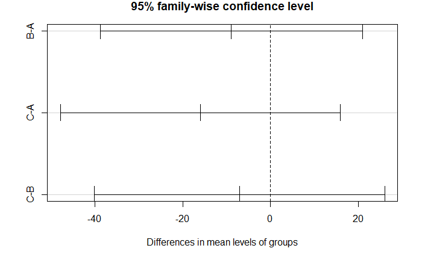

```r
plot(TukeyHSD(result))
```

```r
p.value <- pf(0.804,2,27,lower.tail = F)
p.value
```

```
[1] 0.4579622
```

```r
if(p.value>0.05) {
  print("We cannot reject the null hypothesis")
} else {
  print("we reject the null hypothesis")
}
```

```
[1] "We cannot reject the null hypothesis"
```

```r
print("We cannot reject the null hypothesis that the mean are equal because the p.value of 0.458 (likelihood of equality) is higher than 0.05. There is no significant difference between the means")
```

```
[1] "We cannot reject the null hypothesis that the mean are equal because the p.value of 0.458 (likelihood of equality) is higher than 0.05. There is no significant difference between the means"
```

## Question 4

This is Exercise 10 in Chapter 6 of the Textbook [R].

### Problem

Use the Kruskal–Wallis test (with α = 0.05) to determine whether you should reject the null hypothesis that the means of the four columns of data are equal:

| Col 1 | Col 2 | Col 3 | Col 4 |
| --- | --- | --- | --- |
| 23.1 | 43.1 | 56.5 | 10002.3 |
| 13.3 | 10.2 | 32.1 | 54.4 |
| 15.6 | 16.2 | 43.3 | 8.7 |
| 1.2 | 0.2 | 24.4 | 54.4 |

### Solution

```r
col.1 <- c(23.1,13.3,15.6,1.2)
col.2 <- c(43.1,10.2,16.2,0.2)
col.3 <- c(56.5,32.1,43.3,24.4)
col.4 <- c(10002.3,54.4,8.7,54.4)
df <- data.frame(cbind(col.1,col.2,col.3,col.4))
df
```

| col.1 | col.2 | col.3 | col.4 |
| --- | --- | --- | --- |
| 23.1 | 43.1 | 56.5 | 10002.3 |
| 13.3 | 10.2 | 32.1 | 54.4 |
| 15.6 | 16.2 | 43.3 | 8.7 |
| 1.2 | 0.2 | 24.4 | 54.4 |

```r
col <- stack(df)
col
```

| values | ind |
| --- | --- |
| 23.1 | col.1 |
| 13.3 | col.1 |
| 15.6 | col.1 |
| 1.2 | col.1 |
| 43.1 | col.2 |
| 10.2 | col.2 |
| 16.2 | col.2 |
| 0.2 | col.2 |
| 56.5 | col.3 |
| 32.1 | col.3 |

[output cut: 6 more lines]

```r
result <- kruskal.test(values~ind,data = col)
result
```

```
    Kruskal-Wallis rank sum test

data:  values by ind
Kruskal-Wallis chi-squared = 6.3844, df = 3, p-value = 0.09434
```

```r
if(result$p.value>0.05) {
  print("We cannot reject the null hypothesis")
} else {
  print("we reject the null hypothesis")
}
```

```
[1] "We cannot reject the null hypothesis"
```

```r
print("We cannot reject the null hypothesis that the mean are equal because the p.value of 0.094 (likelihood of equality) is higher than 0.05. There is no significant difference between the means")
```

```
[1] "We cannot reject the null hypothesis that the mean are equal because the p.value of 0.094 (likelihood of equality) is higher than 0.05. There is no significant difference between the means"
```

## Question 5

This is Exercise 12 in Chapter 6 of the Textbook [R].

### Problem

A researcher wishes to know whether distance traveled to work varies by income. Eleven individuals in each of three income groups are surveyed. The resulting data are as follows (in commuting miles, one-way):

```r
## This is the script to generate the table. Do not write your answer inside in this block.
Observations <- seq(1:11)
Low <- c(5,4,1,2,3,10,6,6,4,12,11)
Medium <- c(10,10,8,6,5,3,16,20,7,3,2)
High <- c(8,11,15,19,21,7,7,4,3,17,18)
df <- data.frame(Observations,Low,Medium,High)
library(knitr)
kable(df)
```

| Observations | Low | Medium | High |
| --- | --- | --- | --- |
| 1 | 5 | 10 | 8 |
| 2 | 4 | 10 | 11 |
| 3 | 1 | 8 | 15 |
| 4 | 2 | 6 | 19 |
| 5 | 3 | 5 | 21 |
| 6 | 10 | 3 | 7 |
| 7 | 6 | 16 | 7 |
| 8 | 6 | 20 | 4 |
| 9 | 4 | 7 | 3 |
| 10 | 12 | 3 | 17 |
| 11 | 11 | 2 | 18 |

Use analysis of variance (with α = 0.05) to test the hypothesis that commuting distances do not vary by income. Also evaluate (using R and the Levene test) the assumption of homoscedasticity. Finally, lump all of the data together and produce a histogram, and comment on whether the assumption of normality appears to be satisfied.

### Solution

```r
Low <- c(5,4,1,2,3,10,6,6,4,12,11)
Medium <- c(10,10,8,6,5,3,16,20,7,3,2)
High <- c(8,11,15,19,21,7,7,4,3,17,18)
df <- data.frame(cbind(Low,High,Medium))
df
```

| Low | High | Medium |
| --- | --- | --- |
| 5 | 8 | 10 |
| 4 | 11 | 10 |
| 1 | 15 | 8 |
| 2 | 19 | 6 |
| 3 | 21 | 5 |
| 10 | 7 | 3 |
| 6 | 7 | 16 |
| 6 | 4 | 20 |
| 4 | 3 | 7 |
| 12 | 17 | 3 |

[output cut: 1 more lines]

```r
dist <- stack(df)
dist
```

| values | ind |
| --- | --- |
| 5 | Low |
| 4 | Low |
| 1 | Low |
| 2 | Low |
| 3 | Low |
| 10 | Low |
| 6 | Low |
| 6 | Low |
| 4 | Low |
| 12 | Low |

[output cut: 23 more lines]

```r
result <- aov(values~ind,data = dist)
summary(result)
```

```
            Df Sum Sq Mean Sq F value Pr(>F)
ind          2  201.0  100.48   3.493 0.0433 *
Residuals   30  862.9   28.76
---
Signif. codes:  0 ‘***’ 0.001 ‘**’ 0.01 ‘*’ 0.05 ‘.’ 0.1 ‘ ’ 1
```

```r
TukeyHSD(result)
```

```
  Tukey multiple comparisons of means
    95% family-wise confidence level

Fit: aov(formula = values ~ ind, data = dist)

$ind
                 diff        lwr       upr     p adj
High-Low     6.000000  0.3622571 11.637743 0.0351337
Medium-Low   2.363636 -3.2741065  8.001379 0.5619154
Medium-High -3.636364 -9.2741065  2.001379 0.2653924
```

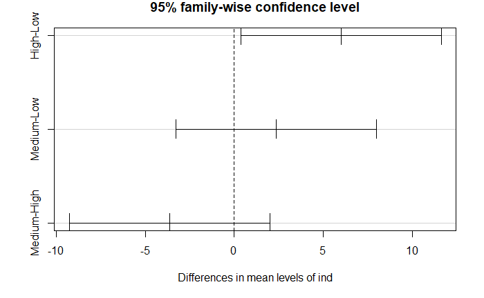

```r
plot(TukeyHSD(result))
```

```r
p.value <- pf(3.493,2,30,lower.tail = F)
p.value
```

```
[1] 0.04327712
```

```r
if(p.value>0.05) {
  print("We cannot reject the null hypothesis")
} else {
  print("we reject the null hypothesis")
}
```

```
[1] "we reject the null hypothesis"
```

```r
#ASSUMPTION OF HOMOSCEDASTICITY
H.test <- leveneTest(values~ind,data = dist)
H.test
```

```
Levene's Test for Homogeneity of Variance (center = median)
      Df F value Pr(>F)
group  2  2.1694 0.1318
      30
```

```r
print("Since p.value is 0.1318, the assumption of homoscedasticity is satisfied.")
```

```
[1] "Since p.value is 0.1318, the assumption of homoscedasticity is satisfied."
```

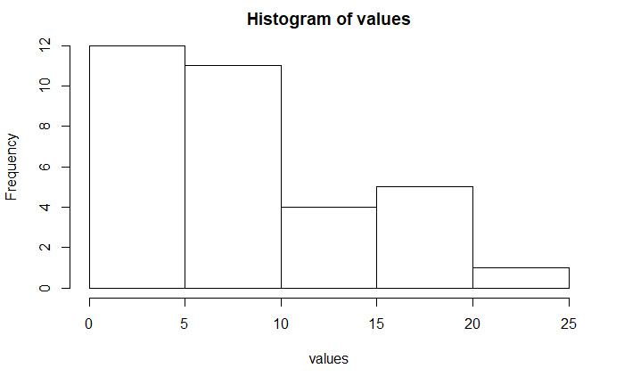

```r
#Histogram and Normality Test
hist(values)
```

```r
norm <- shapiro.test(values)
norm
```

```
    Shapiro-Wilk normality test

data:  values
W = 0.90693, p-value = 0.008099
```

```r
if(norm$p.value>0.05) {
  print("the assumption of normality is satisfied")
} else {
  print("the assumption of normality not satisfied")
}
```

```
[1] "the assumption of normality not satisfied"
```

## Question 6

This is Exercise 13 in Chapter 6 of the Textbook [R].

### Problem

Data are collected on automobile ownership by surveying residents in central cities, suburbs and rural areas. The results are:

|  | Central cities | Suburbs | Rural areas |
| --- | --- | --- | --- |
| Number of observations | 10 | 15 | 15 |
| mean | 1.5 | 2.6 | 1.2 |
| Std. dev | 1.0 | 1.1 | 1.2 |
| Overall mean: 1.725 |  |  |  |
| Overall std.dev: 1.2 |  |  |  |

Test the null hypothesis that the means are equal in all three areas.

### Solution

```r
C <- mvrnorm(10,1.5,1^2,empirical = T)
S <- mvrnorm(15,2.6,1.1^2,empirical = T)
R <- mvrnorm(15,1.2,1.2^2,empirical = T)
x <- c(C,S,R)
y <- c(rep("C",10),rep("S",15),rep("R",15))
df <- data.frame(x,y)
df
```

| x | y |
| --- | --- |
| 2.13211032 | C |
| 0.63447549 | C |
| 1.81114235 | C |
| 2.51488212 | C |
| 2.56069868 | C |
| -0.07734059 | C |
| 1.18835536 | C |
| 2.79570418 | C |
| 0.47646161 | C |
| 0.96351048 | C |

[output cut: 30 more lines]

```r
result <- aov(x~y,data = df)
summary(result)
```

```
            Df Sum Sq Mean Sq F value  Pr(>F)
y            2   15.9   7.950   6.381 0.00416 **
Residuals   37   46.1   1.246
---
Signif. codes:  0 ‘***’ 0.001 ‘**’ 0.01 ‘*’ 0.05 ‘.’ 0.1 ‘ ’ 1
```

```r
TukeyHSD(result)
```

```
  Tukey multiple comparisons of means
    95% family-wise confidence level

Fit: aov(formula = x ~ y, data = df)

$y
    diff         lwr       upr     p adj
R-C -0.3 -1.41257183 0.8125718 0.7888370
S-C  1.1 -0.01257183 2.2125718 0.0531846
S-R  1.4  0.40488550 2.3951145 0.0041221
```

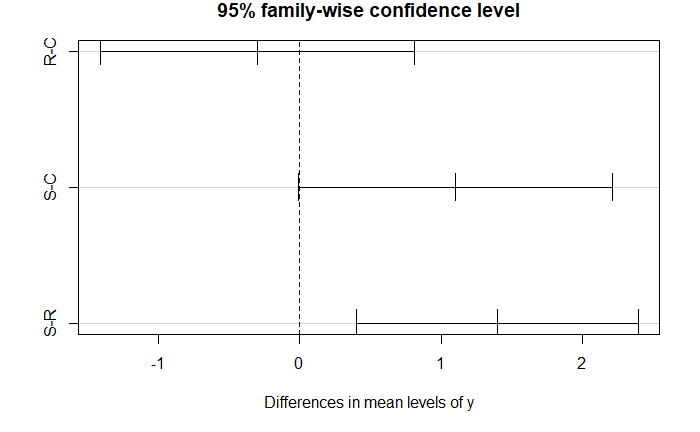

```r
plot(TukeyHSD(result))
```

```r
p.value <- pf(6.381,2,37,lower.tail = F)
p.value
```

```
[1] 0.004160276
```

```r
if(p.value>0.05) {
  print("We cannot reject null the hypothesis")
} else {
  print("We reject the null hypothesis")
}
```

```
[1] "We reject the null hypothesis"
```

```r
print("We reject the null hypothesis that the mean are equal because the p.value of 0.00416 (likelihood of equality) is less than 0.05. There is a significant difference between the means")
```

```
[1] "We reject the null hypothesis that the mean are equal because the p.value of 0.00416 (likelihood of equality) is less than 0.05. There is a significant difference between the means"
```